# Dynamic Documents in R

## Our Normal Workflow

- Load data into R.
- Analyse data in R.
- Produce output results (table/plot)
- Type everything up in Word (maybe tables in Excel).
- There might be an easier way.

## Reproducible Research

- Make your work reproducible (for yourself and for others).
- Word and Excel normally involve a lot of pointing and clicking - hard to reproduce.
- LaTeX might be overkill. Can't run R in LaTeX editor.
- Maybe R Markdown would be of use.

## R Markdown

- Easily produce Word, PDF, HTML and presentations from inside R.
- No copying and pasting images.
- Include your code (or don't - it is up to you).
- Easily run the same analysis on multiple datasets (formatted the same).

## R Markdown

- Developed by R Studio - works with base R too.

```r
install.packages("rmarkdown")
library(rmarkdown)
```

- Takes markdown (type of plain text document) and adds a lot of extras.
- **Knits** document into your chosen format. Using `knitr` package.
- We'll run through a few basics of markdown and then see some examples.

## Markdown Basics

- Markdown lets you do a lot of what you would do in Word.
- Rather than point and clicking uses special syntax.
- For example:
  - Bold: `**this is bold text**` **this is bold text**
  - Italic: `*this is italic text*` *this is italic text*
  - Superscript: `R^2^` R<sup>2</sup>
  - Subscript: `x~2~` x<sub>2</sub>
  - LaTeX: `$$\int_1^2 \frac{1}{x} \: \mathrm{d}x$$` \[\int_1^2 \frac{1}{x} \: \mathrm{d}x\]

## R in Markdown

- Can also add R code directly into document either as "chunks" or inline.
- The same goes for plots. We can include the R code in the output if we wish.

```r
library(ggplot2)
ggplot(mtcars, aes(x = hp, y = mpg)) +
  geom_point(aes(colour = factor(cyl))) +
  geom_smooth() +
  guides(colour = guide_legend(title = "Cylinder"))
```

## R in Markdown

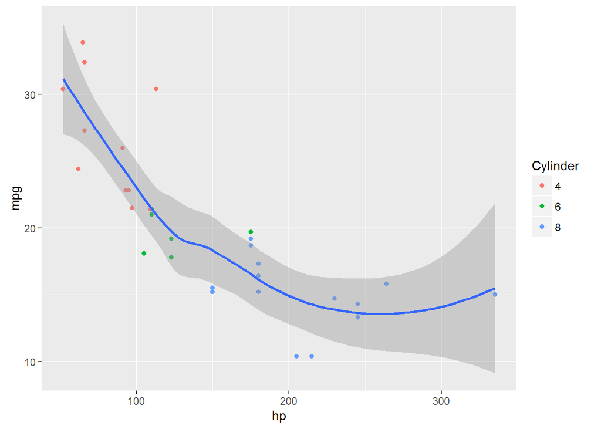

## Rmarkdown Examples

- I'll work through a couple of examples in RStudio first then base R.
- Note:
  - To make a PDF you need LaTeX installed (Open Source).
  - To make a Word doc you need Word/Libre Office installed.

## For those not actually here…

- First we looked at a brand new Rmarkdown file:
  - In RStudio - File → New File → R markdown …
- A more complicated examples is `dyn_docs_demo.Rmd` where R variables are used in the text so only need to be changed in one place.
- This can be compiled by clicking in RStudio or using `render_docs.r`.
- Can also make any R code into a document. Example is `compile_demo.r`. This can be compiled using:
  - In RStudio - File → Compile Notebook (needs to be a `.r` file)
  - Or `rmarkdown::render("compile_demo.r")`

## Summary

- For Rmarkdown create an `.Rmd` file.
- Edit to your heart's content.
- Click `knit` button in RStudio or

```r
rmarkdown::render(input = "my_file.Rmd", output_format = "word_document")
```

- Just scratched the surface - http://rmarkdown.rstudio.com/.
- All notes and documents available on Github - https://github.com/aj2duncan/dyn_docs_pres
- Any questions?